# Simulacion de capas y puntos de presencia

Gerardo Martin

6 de abril de 2018

Gerardo Martín

Este script genera las variables que se van a utilizar en el taller de modelación de nichos con métodos bayesianos. El script está basado en el tutorial para modelar la autocorrelación espacial de Petr Keil (https://www.r-bloggers.com/spatial-autocorrelation-of-errors-in-jags/)

Comenzamos por cargar los paquetes

```r
library(mvtnorm)   # para simular distribuciones normales multivariadas
library(raster)    # para trabajar con objetos de clase ráster
library(foreach)   # para hacer loops de manera mas avanzada
library(dismo)     # para generar las presencias
```

Seguimos declarando las funciones que vamos a usar y sus contenidos

Primero la función que calcula la distancia desde cada píxel a los demás. Esta función sólo requiere como argumento la longitud de los lados. Por el momento sólo trabajaremos con un espacio cuadrado

```r
matriz.dists <- function(long.lado)
{
      coords.filas <- rep(1:long.lado, times=long.lado)
      coords.column <- rep(1:long.lado, each=long.lado)
      filas.column <- data.frame(coords.filas, coords.column)
      D <- dist(filas.column, method="euclidean", diag=TRUE, upper=TRUE)
      D <- as.matrix(D)
      return(D)
}
```

Seguimos con la función que va a simular las variables

```r
sup.correl <- function(long.lado, media.global, lambda){

      require(mvtnorm)

      D <- matriz.dists(long.lado)
      # Aquí se escala la matríz por la función exponencial (puede ser otra función!)
      #Este es el efecto del espacio, las celdas vecinas se parecen más entre si
      SIGMA <- exp(-lambda*D)
      mu <- rep(media.global, times=long.lado*long.lado)
      # Aquí generamos el contenido de la matriz que después será un objeto ráster
      # El contenido será generado con una distribución normal multivariada
      M <- matrix(nrow=long.lado, ncol=long.lado)
      M[] <- rmvnorm(1, mu, SIGMA)
      return(M)
}
```

Y la función que transforma la vairable simulada de matriz a ráster

```r
matriz.a.raster <- function(matriz, extension)
{
      require(raster)

      rast <- raster(matriz)
      rast@extent@xmax <- extension
      rast@extent@ymax <- extension
      return(rast)
}
```

Ahora ya podemos rimular unas superficies….

Para obtener resultados similares vamos a determinar una semilla, que es el número a partir del cuál se generará la serie de números aleatorios

```r
set.seed(14392)
```

Por mis H….s decidí que vamos a trabajar con 5 variables que representarán diversos aspectos del clima. El efecto de la autocorrelación espacial en cada variable será diferente y generado de manera aleatoria con una distribución uniforme, al igual que las medias globales de cada variable. Las lambdas y las medias globales son pasadas en lote a las funciones creadas arriba por medio de foreach

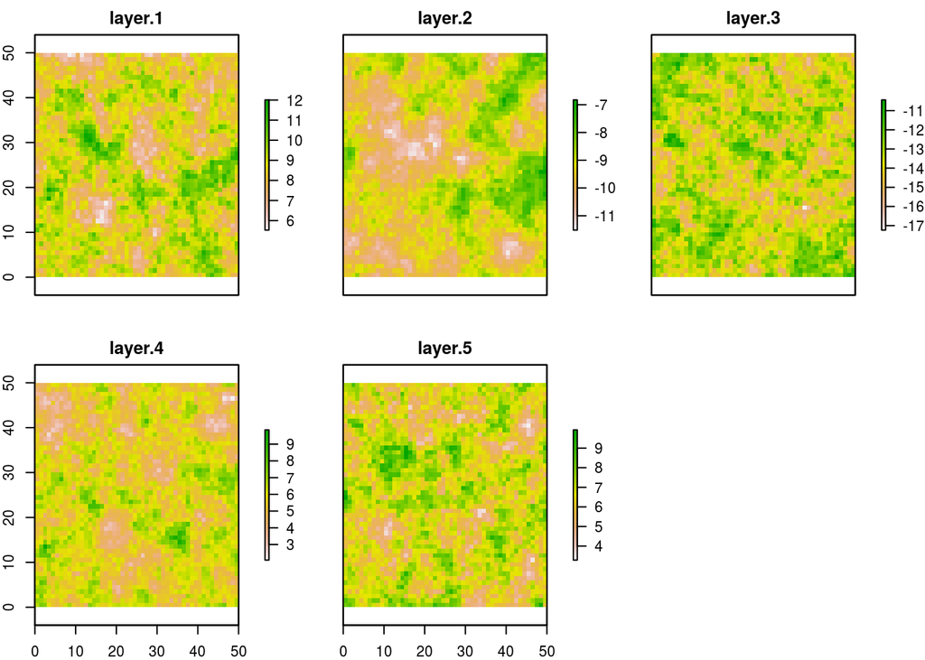

```r
lambdas <- runif(5, 0.01, 0.7) # efectos de autocorrelación
long.lado <- 50 #Tamaño de las capas ráster
medias.globales <- runif(5, -20, 20) #Medias de cada capa
dists <- matriz.dists(long.lado = long.lado)

capas <- foreach(i = seq_along(lambdas)) %do% {
      mat <- sup.correl(long.lado = long.lado, media.global = medias.globales[i], lambda = lambdas[i])
      r <- matriz.a.raster(mat, extension = 50)
      return(r)
}

capas <- stack(capas)

saveRDS(capas, 'capas-experimento.rds')

plot(capas)
```

Ya con las capas creadas podemos generar los puntos de presencia que utilizaremos en los tutoriales que siguen (LGCP y JAGS). Los puntos los vamos a generar con un método que le aprendí al buen lichoso… Distancias de mahalanobis. Para hacer esto: 1. Extraemos todos los datos generados arriba y ponerlos en forma de “data.frame” 2. Generamos la matriz de covarianza (por aquello de las correlaciones y colinearidades) 3. Calculamos las distancias centrando las variables en las medias globales calculadas arriba 4. Transformando las distancias en ráster 5. Transformando las distancias en probabilidades con un modelo logístico

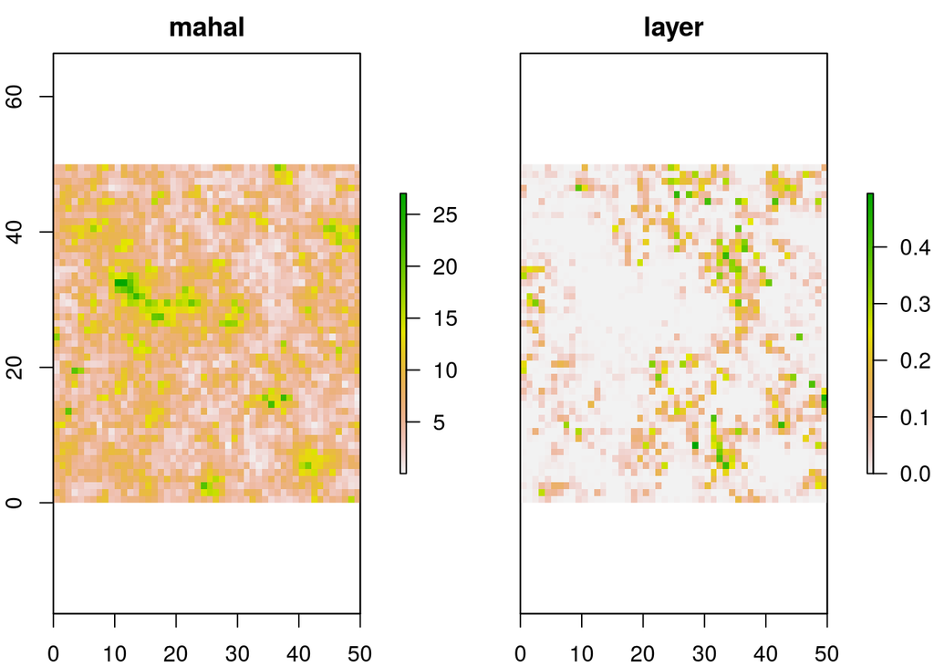

```r
capas.df <- data.frame(rasterToPoints(capas))

cov = cov(capas.df[,paste0('layer.',1:5)])

dist.mahal <- mahalanobis(capas.df[,paste0('layer.',1:5)], center = medias.globales, cov = cov)

dist.r <- rasterFromXYZ(data.frame(capas.df[,c('x', 'y')], mahal = dist.mahal))

prob.pres <- exp(dist.r*(-1))/(1 + exp(dist.r*(-1)))

plot(stack(dist.r, prob.pres))
```

Finalmente con las funciones del paquete dismo podemos generar los puntos de presencia de acuerdo con las probabilidades calculadas arriba.

```r
presencias <- randomPoints(mask = prob.pres, n = 300, prob = T)
```

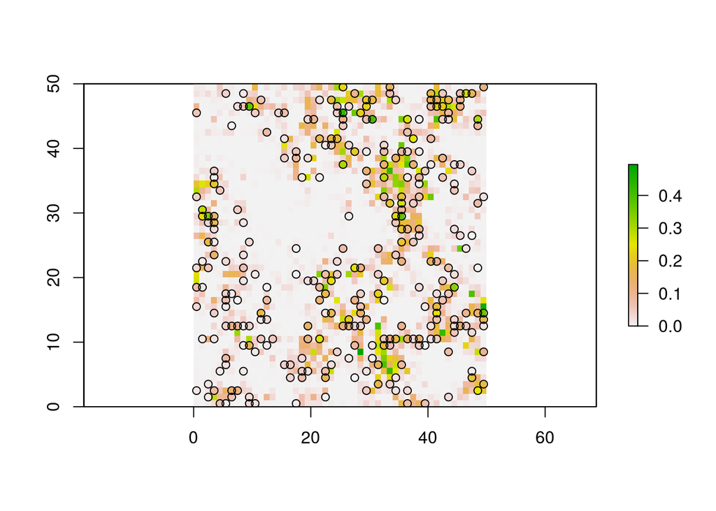

```r
ruido.x <- rnorm(nrow(presencias), 0, sd = 1)
ruido.y <- rnorm(nrow(presencias), 0, sd = 1)

presencias.ruido <- presencias

presencias.ruido[,1] <- presencias.ruido[,1] + ruido.x
presencias.ruido[,2] <- presencias.ruido[,2] + ruido.y

saveRDS(presencias.ruido, 'presencias.rds')

plot(prob.pres); points(presencias)
```

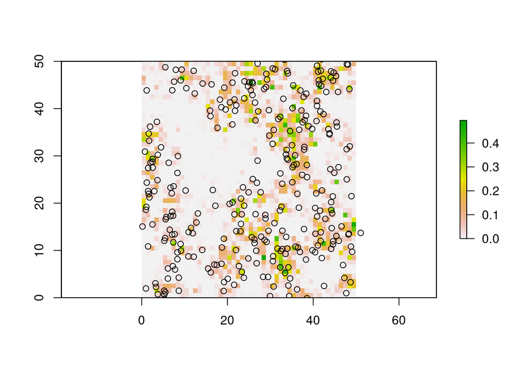

```r
plot(prob.pres); points(presencias.ruido)
```